# A1 - PreProcesado de Datos

Pablo A. Delgado

25 de March, 2021

# Introducción

En esta actividad realizaremos el pre procesado de un fichero de datos que contiene el estilo de juego del videojuego de consola FIFA 2017, así como estadísticas reales de los jugadores de futbol. El conjunto de datos contiene más de 17500 registros y 53 variables.

Las principales variables que se usarán en esta actividad son:

```
•   Name (Nombre del jugador)
•   Nationality (Nacionalidad del jugador)
•   Club_Joining (Fecha en la que empezó en el club)
•   Contract_Expire (Año finalización del contrato)
•   Rating (Valoración global del jugador, entre 0 y 100)
•   Height (Altura)
•   Weight (Peso)
•   Preffered_Foot (Pie preferido)
•   Birth_Date (Fecha de nacimiento)
•   Age (Edad)
•   Work_Rate (valoración cualitativa en términos de ataque-defensa)
```

La descripción de los atributos se puede consultar en https://www.fifplay.com/encyclopedia. La descripción de las abreviaturas de la posición del jugador en el campo se puede consultar en https://www.dtgre.com/2016/10/fifa-17-position-abbreviations-acronyms.html.

El objetivo de esta actividad es preparar el fichero para su posterior análisis. Para ello, se examinará el fichero para detectar y corregir posibles errores, inconsistencias y valores perdidos. Además, se presentará una breve estadística descriptiva y se hará un análisis de componentes principales (PCA) con algunas variables cuantitativas.

**La actividad consta de tres partes diferenciades**:

1. En la primera parte (secciones 2, 3, 4 y 5), se realiza verificaciones y normalización de algunes variables, siguiendo los criterios que se especifican más adelante.
2. En la segunda parte (secciones 6 y 7), se tratan los valores atípicos y los valores perdidos.
3. En la tercera parte (secciones 8 y 9), se calculan algunas métricas de tendencia central y dispersión, que sería el primer paso del análisis descriptivo y, por último, se realiza un análisis de componentes principales (ACP) con algunas variables cuantitativas.

**Criterios de verificación y de normalización de las variables**:

A continuación se muestran los criterios con los que deben limpiarse los datos del conjunto:

1. En los datos numéricos, el símbolo de separador decimal es el punto y no la coma.
2. Verificar si hay registros duplicados con el valor ID. En caso de duplicación, seleccionar el registro con menor numero de NAs en las variables.
3. Las variables Name y Nationality no han de tener espacios en blanco antes o después de su valor. El valor para estas variables han de ser mayúsculas en la primera letra de cada palabra, tal como “Lionel Messi”.
4. La variable Height se ha de expresar en cm con 3 dígitos sin decimales. Para facilitar la lectura y tratamiento del fichero deben ser numéricas, por lo tanto se debe quitar el símbolo de cm.
5. La variable Weight se ha de expresar en kg con 2 dígitos sin decimales. Si hay decimales, se ha de truncar el valor. Para facilitar la lectura y tratamiento del fichero deben ser numéricas, por lo tanto se debe quitar el símbolo de kg.
6. Verificar que la variable Club_Joining está en el rango de los años 1990 a 2017. En caso de haber algún registro que no compla la condición, indicar el número de registro, Name y Club_joining.
7. Verificar que el año de expiración del contracto (Contract_Expiry) no es inferior al año de inicio del contracto(Club_Joining). En caso de haber algún registro que no cumple la condición, indicar el número de registro, Name, Club_Joining y Contract_Expiry.
8. Verificar que la edad (Age) en la fecha 1/1/2017 corresponde a la calculada con la fecha de nacimiento (Birth_Date). En caso de haber algún registro que no cumpla la condición, modificar la edad en función del valor obtenido con la fecha de nacimiento.
9. Verificar que la variable Rating esté entre 0 y 100.
10. La variable Preffered_Foot ha de tener los valores Left y Right que corresponde a los valores actuales de 1 y 2, respectivamente.
11. La variable Work_Rate se basa en la combinación de dos de estas tres categorías: Low, Medium y High. Verificar que se cumple y en caso contrario, hay que corregirlo. Puedes encontrar los nombres de las categorías cortado con tres letras.

# 1. Carga del archivo

Se debe abrir el archivo de datos y examinar el tipo de datos con los que R ha interpretado cada variable. Examinar también los valores resumen de cada tipo de variable.

Como primer paso definimos que librerias estaremos usando. Para ellos generamos un vector con todas las posibles librerias que necesitaremos, instalamos las que no tengamos, para finalmente mediante el uso de lapply cargarlas.

```r
packages <- c("corrplot", "stringr","ggplot2", "stats", "tools", "eeptools", "gridExtra", "psych","factoextra")
new <- packages[!(packages %in% installed.packages()[,"Package"])]
if(length(new)) install.packages(new)
foo=lapply(packages, require, character.only=TRUE)
```

Dado que el input de datos es un archivo csv, y en una inspeccion visual manual hemos visto que posee como separador de columna la coma, usaremos la funcion `read.csv()` para cargar los datos en un dataframe. Vale mencionar que en esta “rapida” inspeccion visual tambien hemos visto que valores como el peso y la altura poseen como separador decimal la coma y en otros casos el punto. Pero dado que estan entre comillas (ademas de estar en unidades distintas), con read.csv no tendremos problemas, nos ocuperamos de normalizar todos estos valores posteriormente. Tambien hemos podido constatar que el csv cuenta con 54 columnas y 17590 lineas, la primera corresponde al header y la ultima una linea en blanco, siendo asi 17588 lineas con datos.

Dicho esto carguemos el archivo y hagamos una verificacion rapida de las primeras y ultimas 5 filas del dataframe.

```r
fifa2017 <- read.csv("fifa_raw.csv", stringsAsFactors = FALSE, header=TRUE)
head(fifa2017)
```

```
##   ID              Name Nationality National_Position National_Kit
## 1  1 Cristiano Ronaldo    Portugal                LS            7
## 2  2      Lionel Messi   Argentina                RW           10
## 3  3            Neymar      Brazil                LW           10
## 4  4       Luis Suárez     Uruguay                LS            9
## 5  5      Manuel Neuer     Germany                GK            1
## 6  6            De Gea       Spain                GK            1
##             Club Club_Position Club_Kit Club_Joining Contract_Expiry Rating
## 1    Real Madrid            LW        7   07/01/2009            2021     94
## 2   FC Barcelona            RW       10   07/01/2004            2018     93
## 3   FC Barcelona            LW       11   07/01/2013            2021     92
## 4   FC Barcelona            ST        9   07/11/2014            2021     92
## 5      FC Bayern            GK        1   07/01/2011            2021     92
## 6 Manchester Utd            GK        1   07/01/2011            2019     90
##   Height    Weight Preffered_Foot Birth_Date Age Preffered_Position
```

[output cut: 48 more lines]

```r
tail(fifa2017)
```

```
##          ID             Name         Nationality National_Position National_Kit
## 17583 17583  Mark McElhinney Republic of Ireland                             NA
## 17584 17584      Adam Dunbar Republic of Ireland                             NA
## 17585 17585     Dylan McGoey Republic of Ireland                             NA
## 17586 17586  Tommy Ouldridge             England                             NA
## 17587 17587       Mark Foden            Scotland                             NA
## 17588 17588 Barry Richardson             England                             NA
##                 Club Club_Position Club_Kit Club_Joining Contract_Expiry Rating
## 17583     Derry City           Res       20   01/01/2016            2017     45
## 17584 Wexford Youths           Sub       30   02/01/2016            2020     45
## 17585  Longford Town           Sub       28   01/01/2016            2020     45
## 17586   Swindon Town           Res       32   03/03/2015            2023     45
## 17587    Ross County           Sub       45   03/02/2016            2017     45
## 17588        Wycombe           Sub       13   01/30/2014            2023     45
##       Height    Weight Preffered_Foot Birth_Date Age Preffered_Position
```

[output cut: 48 more lines]

Veamos la cantidad de columnas, filas y como quedaron los tipos de datos en el dataframe para entender luego como hacer el trabajo de preprocesado de los mismos.

```r
str(fifa2017)
```

```
## 'data.frame':    17588 obs. of  54 variables:
##  $ ID                : int  1 2 3 4 5 6 7 8 9 10 ...
##  $ Name              : chr  "Cristiano Ronaldo" "Lionel Messi" "Neymar" "Luis Suárez" ...
##  $ Nationality       : chr  "Portugal" "Argentina" "Brazil" "Uruguay" ...
##  $ National_Position : chr  "LS" "RW" "LW" "LS" ...
##  $ National_Kit      : int  7 10 10 9 1 1 9 11 NA 1 ...
##  $ Club              : chr  "Real Madrid" "FC Barcelona" "FC Barcelona" "FC Barcelona" ...
##  $ Club_Position     : chr  "LW" "RW" "LW" "ST" ...
##  $ Club_Kit          : int  7 10 11 9 1 1 9 11 9 13 ...
##  $ Club_Joining      : chr  "07/01/2009" "07/01/2004" "07/01/2013" "07/11/2014" ...
##  $ Contract_Expiry   : int  2021 2018 2021 2021 2021 2019 2021 2022 2017 2019 ...
##  $ Rating            : int  94 93 92 92 92 90 90 90 90 89 ...
##  $ Height            : chr  "1,85 m" NA "1,74 m" "1,82 m" ...
##  $ Weight            : chr  NA "72475 gr" "68884 gr" "85511 gr" ...
##  $ Preffered_Foot    : int  2 1 2 2 2 2 2 1 2 1 ...
```

[output cut: 40 more lines]

```r
nrow(fifa2017)
```

```
## [1] 17588
```

```r
ncol(fifa2017)
```

```
## [1] 54
```

En principio como vemos, 17588 obs. of 54 variables, la cantidad de filas y columnas en el dataframe coinciden con la inspecion visual que hemos hecho sobre el archivo csv.

En cuanto a los tipos de datos es evidente que tendremos que normalizar varias variables, cambiar tipos de datos, completar valores vacios, etc.. como puede verse facilmente con por ej las variables: Height, Weight, National_Kit, etc…

Veamos cuales son las estadisticas basicas tal como tenemos hasta ahora el dataframe sin ningun trabajo de procesado por el momento:

```r
summary(fifa2017)
```

```
##        ID            Name           Nationality        National_Position
##  Min.   :    1   Length:17588       Length:17588       Length:17588
##  1st Qu.: 4398   Class :character   Class :character   Class :character
##  Median : 8794   Mode  :character   Mode  :character   Mode  :character
##  Mean   : 8794
##  3rd Qu.:13191
##  Max.   :17588
##
##   National_Kit       Club           Club_Position         Club_Kit
##  Min.   : 1.00   Length:17588       Length:17588       Min.   : 1.00
##  1st Qu.: 6.00   Class :character   Class :character   1st Qu.: 9.00
##  Median :12.00   Mode  :character   Mode  :character   Median :18.00
##  Mean   :12.22                                         Mean   :21.29
##  3rd Qu.:18.00                                         3rd Qu.:27.00
##  Max.   :36.00                                         Max.   :99.00
##  NA's   :16513                                         NA's   :1
##  Club_Joining       Contract_Expiry     Rating         Height
##  Length:17588       Min.   :2017    Min.   :45.00   Length:17588
##  Class :character   1st Qu.:2017    1st Qu.:62.00   Class :character
##  Mode  :character   Median :2019    Median :66.00   Mode  :character
##                     Mean   :2019    Mean   :66.17
##                     3rd Qu.:2020    3rd Qu.:71.00
##                     Max.   :2023    Max.   :94.00
##                     NA's   :1
##     Weight          Preffered_Foot   Birth_Date             Age
##  Length:17588       Min.   :1.000   Length:17588       Min.   :17.00
##  Class :character   1st Qu.:2.000   Class :character   1st Qu.:22.00
##  Mode  :character   Median :2.000   Mode  :character   Median :25.00
##                     Mean   :1.767                      Mean   :25.46
##                     3rd Qu.:2.000                      3rd Qu.:29.00
##                     Max.   :2.000                      Max.   :47.00
##
##  Preffered_Position  Work_Rate           Weak_foot      Skill_Moves
##  Length:17588       Length:17588       Min.   :1.000   Min.   :1.000
##  Class :character   Class :character   1st Qu.:3.000   1st Qu.:2.000
##  Mode  :character   Mode  :character   Median :3.000   Median :2.000
##                                        Mean   :2.934   Mean   :2.303
##                                        3rd Qu.:3.000   3rd Qu.:3.000
##                                        Max.   :5.000   Max.   :5.000
##
```

[output cut: 49 more lines]

```
##  Min.   : 4.00     Min.   : 7.00   Min.   : 3.00   Min.   : 1.00
##  1st Qu.:31.00     1st Qu.:39.00   1st Qu.:30.00   1st Qu.: 8.00
##  Median :42.00     Median :50.00   Median :44.00   Median :11.00
##  Mean   :43.38     Mean   :49.17   Mean   :43.28   Mean   :16.61
##  3rd Qu.:57.00     3rd Qu.:61.00   3rd Qu.:57.00   3rd Qu.:14.00
##  Max.   :93.00     Max.   :96.00   Max.   :93.00   Max.   :91.00
##
##    GK_Diving       GK_Kicking     GK_Handling     GK_Reflexes
##  Min.   : 1.00   Min.   : 1.00   Min.   : 1.00   Min.   : 1.0
##  1st Qu.: 8.00   1st Qu.: 8.00   1st Qu.: 8.00   1st Qu.: 8.0
##  Median :11.00   Median :11.00   Median :11.00   Median :11.0
##  Mean   :16.82   Mean   :16.46   Mean   :16.56   Mean   :16.9
##  3rd Qu.:14.00   3rd Qu.:14.00   3rd Qu.:14.00   3rd Qu.:14.0
##  Max.   :89.00   Max.   :95.00   Max.   :91.00   Max.   :90.0
##
```

Como hemos visto arriba, muchas variables cuantitivas se cargaron por default como character, ademas de como hemos dicho antes, incluso como character tampoco estan en el mismo formato por lo que deberemos normalizar las unidades de varias variables al convertirlas de character a numeric o integer (cuantitativas continuas o cuantitativas discretas). O incluso tambien normalizar si fuera la conversion a cualitativas si correspondiense.

Tambien puede evidenciarse arriba que tenemos incluso casos de variables categoricas ocultas como cuantitativas, como por ej la variable Preffered_Foot, que toma valores 1 o 2. Fue importada por default por la funcion read.csv como integer, siendo posible considerarla como Categorica Nominal.

# 2. Verificar duplicación de registros

Verifiquemos si hay registros duplicados a partir del valor ID. En caso que existan duplicados, seleccionaremos el registro con menor numero de NAs en las variables.

```r
length(fifa2017$ID)
```

```
## [1] 17588
```

```r
length(unique(fifa2017$ID))
```

```
## [1] 17588
```

Como vemos aqui, la cantidad de observaciones son coincidentes con y sin aplicar la funcion unique, por lo que podemos concluir que no existen duplicados por el campo ID.

# 3. Normalización de los datos cuantitativos

Inspeccionar los valores de los datos cuantitativos y realizar las normalizaciones oportunas siguiendo los criterios especificados anteriormente. Estas normalizaciones tienen como objetivo uniformizar los formatos. Si hay valores perdidos o valores extremos, se tratarán más adelante.

Al realizar estas normalizaciones, se debe demostrar que la normalización sobre cada variable ha dado el resultado esperado. Por lo tanto, se recomienda mostrar un fragmento del archivo de datos resultante. Para evitar mostrar todo el conjunto de datos, se puede mostrar una parte del mismo, con las funciones head y/o tail.

Puntos a tener en cuenta:

```
- En los datos numéricos, el símbolo de separador decimal es el punto y no la coma.
- Verificar que la variable Rating esté entre 0 y 100.
- La variable Height se ha de expresar en cm con 3 dígitos sin decimales. Para facilitar la lectura y tratamiento del fichero deben ser numéricas, por lo tanto se debe quitar el símbolo de cm.
- La variable Weight se ha de expresar en kg, sin decimales. Si hay decimales, se ha de truncar el valor. Para facilitar la lectura y tratamiento del fichero deben ser numéricas, por lo tanto se debe quitar el símbolo de kg.
```

## 3.1. Rating

Primero verificamos jugadores que tenga un rating fuera del rango de 0 a 90:

```r
fifa2017[!(fifa2017$Rating >= 0 & fifa2017$Rating <=90), c("ID","Name", "Rating")]
```

```
##   ID              Name Rating
## 1  1 Cristiano Ronaldo     94
## 2  2      Lionel Messi     93
## 3  3            Neymar     92
## 4  4       Luis Suárez     92
## 5  5      Manuel Neuer     92
```

Por lo que vemos arriba justamente son los cracks los que tienen valores por encima de 90, pero dicho esto y lo que estamos visualizando, no existen jugadores con un rating por encima de 100, ni mucho menos por debajo de 0. Reconfirmemoslo con la siguiente sentencia:

```r
fifa2017[!(fifa2017$Rating >= 0 & fifa2017$Rating <=100), c("ID","Name", "Rating")]
```

```
## [1] ID     Name   Rating
## <0 rows> (or 0-length row.names)
```

## 3.2. Height

Como sabemos y vemos aqui debemos llevar a la misma unidad la variable altura, a cm y sin decimales:

```r
fifa2017$Height[1:20]
```

```
##  [1] "1,85 m" NA       "1,74 m" "1,82 m" "1,93 m" NA       "1,85 m" "1,83 m"
##  [9] NA       "1,99 m" "1,92 m" "1,73 m" "1,74 m" "180 cm" "184 cm" "183 cm"
## [17] "1,83 m" "173 cm" "191 cm" "176 cm"
```

Como primer paso verifiquemos que la cantidad de missing values, y la cantidad de observaciones con la unidad cm y m coincida con el total de observaciones: 17588

```r
length(grep(' cm', fifa2017$Height)) +
length(grep(' m', fifa2017$Height)) +
table(is.na(fifa2017$Height))["TRUE"]
```

```
##  TRUE
## 17588
```

Dicho, esto llevemos ahora todos las observaciones en metros directamente a centimetros aqui:

```r
fifa2017$Height = str_replace_all(fifa2017$Height, "[cm ,]", "")
fifa2017$Height = as.integer(str_pad(fifa2017$Height, 3, side = c("right"), pad = "0"))
```

Verifiquemos que el tipo de dato sea integer y grafiquemos un sencillo grafico de barras para visualizar si los datos de altura quedaron ok

```r
class(fifa2017$Height)
```

```
## [1] "integer"
```

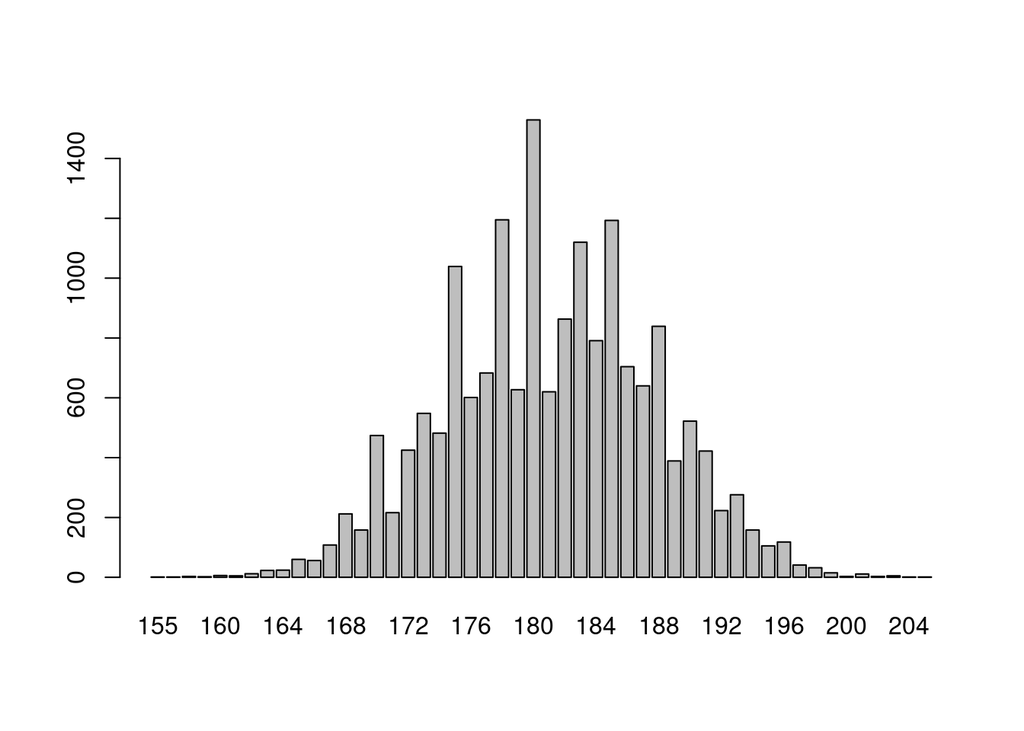

```r
#ggplot(data=as.data.frame(fifa2017$Height), aes(x=fifa2017$Height))+geom_bar()
barplot(table(fifa2017$Height))
```

## 3.3. Weight

La variable Weight se ha de expresar en kg, sin decimales. Si hay decimales, se ha de truncar el valor. Para facilitar la lectura y tratamiento del fichero deben ser numéricas, por lo tanto se debe quitar el símbolo de kg.

Si observamos este sampleo de datos, vemos que para separar los decimales cuando la unidad es kg se usan indistintamente comas o puntos, mientras que cuando tenemos solo gramos no se usa ningun tipo de separador.

```r
head(fifa2017$Weight,20)
```

```
##  [1] NA          "72475 gr"  "68884 gr"  "85511 gr"  NA          "82.671 kg"
##  [7] NA          "74683 gr"  "95.429 kg" "91394 gr"  "90865 gr"  "74579 gr"
## [13] "65474 gr"  "76,777 kg" "92,443 kg" "79,164 kg" "75432 gr"  "70.238 kg"
## [19] "84.588 kg" "67.393 kg"
```

Hagamos un check mas para el caso de gramos:

```r
length(grep('gr', fifa2017$Weight))
```

```
## [1] 122
```

Dado que son pocos registros, verifiquemos que no exista ningun tipo de separador.

```r
fifa2017[grep('gr', fifa2017$Weight),]$Weight
```

```
##   [1] "72475 gr" "68884 gr" "85511 gr" "74683 gr" "91394 gr" "90865 gr"
##   [7] "74579 gr" "65474 gr" "75432 gr" "78729 gr" "92828 gr" "66268 gr"
##  [13] "81269 gr" "68736 gr" "75872 gr" "75132 gr" "78141 gr" "85442 gr"
##  [19] "80493 gr" "76249 gr" "75331 gr" "76306 gr" "70661 gr" "68645 gr"
##  [25] "85245 gr" "75487 gr" "79656 gr" "74366 gr" "72180 gr" "78514 gr"
##  [31] "75512 gr" "81369 gr" "73378 gr" "78135 gr" "74444 gr" "84778 gr"
##  [37] "65214 gr" "84629 gr" "76734 gr" "73772 gr" "68624 gr" "84446 gr"
##  [43] "80403 gr" "85233 gr" "62602 gr" "75744 gr" "83885 gr" "86595 gr"
##  [49] "70391 gr" "69439 gr" "75162 gr" "85518 gr" "80553 gr" "77411 gr"
##  [55] "78850 gr" "83393 gr" "84308 gr" "90153 gr" "71863 gr" "70701 gr"
##  [61] "72732 gr" "85349 gr" "71824 gr" "75672 gr" "71640 gr" "84602 gr"
##  [67] "67308 gr" "74225 gr" "71282 gr" "78518 gr" "81322 gr" "85401 gr"
##  [73] "68498 gr" "70447 gr" "84889 gr" "71577 gr" "66216 gr" "69386 gr"
##  [79] "86456 gr" "75353 gr" "74366 gr" "81561 gr" "77699 gr" "98343 gr"
##  [85] "84692 gr" "65667 gr" "77684 gr" "80185 gr" "70518 gr" "72185 gr"
##  [91] "70160 gr" "65430 gr" "75153 gr" "64227 gr" "72186 gr" "83242 gr"
##  [97] "75772 gr" "70854 gr" "89611 gr" "81704 gr" "66322 gr" "80415 gr"
## [103] "67336 gr" "65682 gr" "78735 gr" "77585 gr" "70546 gr" "78736 gr"
## [109] "82187 gr" "65789 gr" "80489 gr" "75525 gr" "78517 gr" "72125 gr"
## [115] "60649 gr" "64157 gr" "60196 gr" "69490 gr" "84391 gr" "77772 gr"
## [121] "80505 gr" "78474 gr"
```

Por lo tanto, para obtener lo solicitado haremos:

```
1. Dado que el símbolo de separador decimal es el punto y no la coma, cambiaremos todos las comas por puntos
2. Identificamos los indices con el valor gr
3. Identificamos los indices con el valor kg
4. Para los elementos del grupo gr, les quitamos el string gr, convertimos a numerico, dividimos por 1000 para convertir a kilogramos y luego truncamos decimales.
5. Para los elementos del grupo kg, les quitamos el string kg, convertimos a numerico y luego truncamos decimales
```

Veamos y ejecutemos ahora el codigo para realizar esos pasos:

```r
# Dado que el símbolo de separador decimal es el punto y no la coma, realizamos la conversion:
fifa2017$Weight = str_replace_all(fifa2017$Weight, ",", ".")

# Detectamos los indices con unidad kg y los correspondientes a gr
indexes_gr = grep('gr', fifa2017$Weight)
indexes_kg = grep('kg', fifa2017$Weight)


# Chequeamos cantidades
length(indexes_gr)
```

```
## [1] 122
```

```r
length(indexes_kg)
```

```
## [1] 17463
```

```r
# Hacemos una previsualizacion de ambos
head(fifa2017[indexes_gr,]$Weight,10)
```

```
##  [1] "72475 gr" "68884 gr" "85511 gr" "74683 gr" "91394 gr" "90865 gr"
##  [7] "74579 gr" "65474 gr" "75432 gr" "78729 gr"
```

```r
head(fifa2017[indexes_kg,]$Weight,10)
```

```
##  [1] "82.671 kg" "95.429 kg" "76.777 kg" "92.443 kg" "79.164 kg" "70.238 kg"
##  [7] "84.588 kg" "67.393 kg" "68.275 kg" "76.384 kg"
```

```r
# Dividimos por 1000 los valores correspondientes a gr y truncamos los decimales
fifa2017[indexes_gr,]$Weight = trunc(as.numeric(str_replace_all(fifa2017[indexes_gr,]$Weight, "[ gr]", ""))/1000)

# Convertimos los valores correspondientes a kg a numerico y truncamos los decimales
fifa2017[indexes_kg,]$Weight = trunc(as.numeric(str_replace_all(fifa2017[indexes_kg,]$Weight, "[ kg]", "")))
fifa2017$Weight = as.integer(fifa2017$Weight)

# previsualicemos algunos valores
head(fifa2017$Weight,20)
```

```
##  [1] NA 72 68 85 NA 82 NA 74 95 91 90 74 65 76 92 79 75 70 84 67
```

# 4. Normalización de los datos cualitativos

Inspeccionar los valores de los datos cualitativos y realizar las transformaciones oportunas, siguiendo los criterios especificados. Al igual que en el apartado anterior, mostrar el resultado sobre un fragmento del conjunto de datos.

## 4.1. Name y Nationality

Las variables Name y Nationality no han de tener espacios en blanco antes o después de su valor. El valor para estas variables han de ser mayúsculas en la primera letra de cada palabra, tal como “Lionel Messi”.

Como vemos en este sampleo, puede verificarse algunos de los puntos comentado en el parrafo anterior, incluso para los paises en algunos casos esta todo en mayuscula, por ej: ENGLAND, por lo que debera convertirse a England, segun lo definido.

```r
head(fifa2017$Name,20)
```

```
##  [1] "Cristiano Ronaldo"   "Lionel Messi"        "Neymar"
##  [4] "Luis Suárez"         "Manuel Neuer"        "De Gea"
##  [7] "robert Lewandowski " "Gareth Bale"         "Zlatan Ibrahimovic"
## [10] "Thibaut Courtois"    "Jérôme Boateng"      "Eden Hazard"
## [13] "Luka Modric"         "mesut Özil   "       "Gonzalo Higuaín"
## [16] "Thiago Silva"        "Sergio Ramos"        "sergio Agüero   "
## [19] "Paul Pogba"          "Antoine Griezmann"
```

```r
tail(fifa2017$Nationality,20)
```

```
##  [1] "Republic of Ireland" "England"             "Republic of Ireland"
##  [4] "Republic of Ireland" "Germany"             "Northern Ireland"
##  [7] "Republic of Ireland" "England"             "England"
## [10] "ENGLAND"             "England"             "England"
## [13] "England"             "England"             "Republic of Ireland"
## [16] "Republic of Ireland" "Republic of Ireland" "England"
## [19] "Scotland"            "England"
```

Ejecutemos el codigo para realizar la transformacion:

```r
# quitamos espacios en los extremos
fifa2017$Name=str_trim(fifa2017$Name, side = c("both"))
fifa2017$Nationality=str_trim(fifa2017$Nationality, side = c("both"))

# convertimos todo a minusculas, para igualar primero todas las palabras, por ej England e ENGLAND, a england
fifa2017$Name = tolower(fifa2017$Name)
fifa2017$Nationality = tolower(fifa2017$Nationality)


# para finalmente convertir a mayuscula cada palabra de cada cada observacion
fifa2017$Name = toTitleCase(fifa2017$Name)
fifa2017$Nationality = toTitleCase(fifa2017$Nationality)
```

Volvamos a verificar que se haya realizado el ajuste correctamente:

```r
head(fifa2017$Name,20)
```

```
##  [1] "Cristiano Ronaldo"  "Lionel Messi"       "Neymar"
##  [4] "Luis Suárez"        "Manuel Neuer"       "De Gea"
##  [7] "Robert Lewandowski" "Gareth Bale"        "Zlatan Ibrahimovic"
## [10] "Thibaut Courtois"   "Jérôme Boateng"     "Eden Hazard"
## [13] "Luka Modric"        "Mesut Özil"         "Gonzalo Higuaín"
## [16] "Thiago Silva"       "Sergio Ramos"       "Sergio Agüero"
## [19] "Paul Pogba"         "Antoine Griezmann"
```

```r
tail(fifa2017$Nationality,20)
```

```
##  [1] "Republic of Ireland" "England"             "Republic of Ireland"
##  [4] "Republic of Ireland" "Germany"             "Northern Ireland"
##  [7] "Republic of Ireland" "England"             "England"
## [10] "England"             "England"             "England"
## [13] "England"             "England"             "Republic of Ireland"
## [16] "Republic of Ireland" "Republic of Ireland" "England"
## [19] "Scotland"            "England"
```

## 4.2. Preffered_Foot

La variable Preffered_Foot ha de tener los valores Left y Right que corresponde a los valores actuales de 1 y 2, respectivamente.

En primer instancia verifiquemos los valores posibles de esta variable:

```r
table(fifa2017$Preffered_Foot)
```

```
##
##     1     2
##  4094 13494
```

Veamos el codigo para realizar la transformacion:

```r
fifa2017[(fifa2017$Preffered_Foot==1),]$Preffered_Foot = 'Left'
fifa2017[(fifa2017$Preffered_Foot==2),]$Preffered_Foot = 'Right'
```

Verifiquemos el resultado de la modificacion:

```r
table(fifa2017$Preffered_Foot)
```

```
##
##  Left Right
##  4094 13494
```

## 4.3. Work_Rate

La variable Work_Rate se basa en la combinación de dos de estas tres categorías: Low, Medium y High. Verificar que se cumple y en caso contrario, hay que corregirlo. Puedes encontrar los nombres de las categorías cortado con tres letras.

En primer instancia verifiquemos los valores posibles de esta variable:

```r
table(fifa2017$Work_Rate)
```

```
##
##       Hig / Med     High / High      High / Low   High / Medium      Low / High
##              86             747             730            2832             438
##       Low / Low    Low / Medium       Med / Med   Medium / High    Medium / Low
##              30             449             268            1534             845
## Medium / Medium
##            9629
```

```r
sum(table(fifa2017$Work_Rate))
```

```
## [1] 17588
```

Por lo que vemos arriba, deberemos por ej renombrar casos como: Hig a High Med a Medium

```r
fifa2017$Work_Rate = str_replace(fifa2017$Work_Rate, "Hig /", "High /")
fifa2017$Work_Rate = str_replace(fifa2017$Work_Rate, "/ Hig$", "/ High")
fifa2017$Work_Rate = str_replace(fifa2017$Work_Rate, "Med /", "Medium /")
fifa2017$Work_Rate = str_replace(fifa2017$Work_Rate, "/ Med$", "/ Medium")
```

Vemos ahora como se han reagrupado correctamente las observaciones

```r
table(fifa2017$Work_Rate)
```

```
##
##     High / High      High / Low   High / Medium      Low / High       Low / Low
##             747             730            2918             438              30
##    Low / Medium   Medium / High    Medium / Low Medium / Medium
##             449            1534             845            9897
```

y los valores totales siguen cuadrando:

```r
sum(table(fifa2017$Work_Rate))
```

```
## [1] 17588
```

# 5. Posibles inconsistencias y variables tipo fecha

Verificar si existen inconsistencias entre algunas variables. Por otra parte, algunas de las variables es necesario indicar que son de tipo fecha (en r, tipo Date) para luego hacer las transformaciones adecuadas. Observar que la configuración del tipo fecha es mes/día/año. Al igual que en el apartado anterior, muestre el resultado sobre un fragmento del conjunto de datos.

## 5.1. Club_Joining

Verificar que la variable Club_Joining está en el rango de los años 1990 a 2017. En caso de haber algún registro que no cumpla la condición, indicar el número de registro, Name y Club_joining.

Para esto primero convertimos el campo a date, ya que como vemos es del tipo character:

```r
class(fifa2017$Club_Joining)
```

```
## [1] "character"
```

```r
typeof(fifa2017$Club_Joining)
```

```
## [1] "character"
```

Luego verificamos si hay algun formato incorrecto al intentar convertir a date:

```r
indexs_date_ok = which(!is.na(as.Date(fifa2017$Club_Joining, "%m/%d/%Y")))
indexs_date_nook =  which(is.na(as.Date(fifa2017$Club_Joining, "%m/%d/%Y")))
length(indexs_date_ok)
```

```
## [1] 17587
```

```r
length(indexs_date_nook)
```

```
## [1] 1
```

Como vemos no hay ninguno, solo 1 registro vacio.

```r
fifa2017[indexs_date_nook,]$Club_Joining
```

```
## [1] ""
```

Prosigamos:

```r
fifa2017$Club_Joining = as.Date(fifa2017$Club_Joining, "%m/%d/%Y")
head(fifa2017$Club_Joining)
```

```
## [1] "2009-07-01" "2004-07-01" "2013-07-01" "2014-07-11" "2011-07-01"
## [6] "2011-07-01"
```

Para finalmente ver los jugadores donde su Club_Joining no está en el rango de los años 1990 a 2017, mostrando su ID, Nombre y Fecha.

```r
# Previsualizamos la cantidad de jugadores distribuidos por año
table(format(fifa2017$Club_Joining, format = "%Y"))
```

```
##
## 1991 1993 1998 1999 2000 2001 2002 2003 2004 2005 2006 2007 2008 2009 2010 2011
##    1    1    4    3    1    9   22   23   26   29   38   80  125  189  315  450
## 2012 2013 2014 2015 2016 2017
##  853 1294 2278 4030 6026 1790
```

```r
# Mostramos los que no cumplen la condicion requerida
cols = c("ID", "Name", "Club_Joining")
fifa2017[!(fifa2017$Club_Joining >= as.Date('1990-01-01') & fifa2017$Club_Joining < as.Date('2018-01-01') ), cols ]
```

```
##    ID Name Club_Joining
## NA NA <NA>         <NA>
```

Como finalmente vemos todos estan en el rango definido, ya que estamos considerando del 1 de enero de 1990 al 31 de diciembre de 2017.

## 5.2. Contract_Expiry >= Club_Joining?

Verificar que el año de expiración del contracto (Contract_Expiry) no es inferior al año de inicio del contracto(Club_Joining). En caso de haber algún registro que no cumple la condición, indicar el número de registro, Name, Club_Joining y Contract_Expiry.

Realizamos primero un sampleo de las observaciones por Contract_Expiry.

```r
table(fifa2017$Contract_Expiry)
```

```
##
## 2017 2018 2019 2020 2021 2022 2023
## 4529 4074 2844 3488  975  783  894
```

Para luego mostrar lo solicitado

```r
cols = c("ID", "Name", "Club_Joining", "Contract_Expiry")
years_club_Joining = format(fifa2017$Club_Joining, format = "%Y")
fifa2017[!(fifa2017$Contract_Expiry >= years_club_Joining ), cols ]
```

```
##    ID Name Club_Joining Contract_Expiry
## NA NA <NA>         <NA>              NA
```

Como puede verse no hay registros donde el año de expiracion sea anterior al año de incorporacion al equipo.

Si es verdad que hay casos de jugadores que se unen a un equipo y su contrato expira ese mismo año, como por ejemplo estos casos:

```r
nrow(fifa2017[fifa2017$Contract_Expiry == years_club_Joining,])
```

```
## [1] 342
```

```r
head(fifa2017[fifa2017$Contract_Expiry == years_club_Joining, cols])
```

```
##      ID              Name Club_Joining Contract_Expiry
## 344 344    Martín Cáceres   2017-02-16            2017
## NA   NA              <NA>         <NA>              NA
## 680 680  Jefferson Farfán   2017-01-29            2017
## 764 764 Agustín Marchesín   2017-01-01            2017
## 897 897 Martín Demichelis   2017-01-17            2017
## 903 903    Mathieu Bodmer   2017-01-23            2017
```

## 5.3. Revisar si la edad corresponde a la fecha de nacimiento

Verificar que la edad (Age) en la fecha 1/1/2017 corresponde a la calculada con la fecha de nacimiento (Birth_Date). En caso de haber algún registro que no cumpla la condición, modificar la edad en función del valor obtenido con la fecha de nacimiento.

En primer instancia verifiquemos el campo birth_date y age

```r
table(fifa2017$Age)
```

```
##
##   17   18   19   20   21   22   23   24   25   26   27   28   29   30   31   32
##  157  533 1004 1208 1196 1283 1356 1296 1447 1195 1134 1071 1104  852  668  567
##   33   34   35   36   37   38   39   40   41   42   43   44   47
##  598  317  236  159  102   50   24   16    6    2    3    3    1
```

```r
class(fifa2017$Birth_Date)
```

```
## [1] "character"
```

```r
head(fifa2017$Birth_Date)
```

```
## [1] "02/05/1985" "06/24/1987" "02/05/1992" "01/24/1987" "03/27/1986"
## [6] "11/07/1990"
```

Ahora asumiendo que se quiere calcular las edades al 1 de enero de 2017, vamos a verificar si el campo edad que nos viene informado en el csv es igual o no a la diferencia entre esta fecha (1/1/2017) y la fecha de nacimiento de cada jugador:

```r
# primero convertimos a fecha el birth_date
fifa2017$Birth_Date = as.Date(fifa2017$Birth_Date, "%m/%d/%Y")

calculated_ages =  trunc(age_calc(fifa2017$Birth_Date, enddate = as.Date('2017-01-01') , units = "years", precise = TRUE))

nrow(fifa2017[fifa2017$Age != calculated_ages, ])
```

```
## [1] 5561
```

Como vemos hay 5561 casos donde la edad no es la misma, ajustemos esos valores de edad al 1/1/2017

```r
index_ages_to_fix = which(fifa2017$Age != calculated_ages)
fifa2017[index_ages_to_fix,]$Age = calculated_ages[index_ages_to_fix]
```

Volvamos a verificar que ahora ya no existan diferencias:

```r
nrow(fifa2017[fifa2017$Age != calculated_ages, ])
```

```
## [1] 0
```

Hagamos un pequeño sampleo del resultado de ambos grupos, de los ok, como de los que se corrigieron

```r
cols = c("Name", "Age", "Birth_Date")
head(fifa2017[-index_ages_to_fix,cols],20)
```

```
##                  Name Age Birth_Date
## 2        Lionel Messi  29 1987-06-24
## 6              De Gea  26 1990-11-07
## 7  Robert Lewandowski  28 1988-08-21
## 8         Gareth Bale  27 1989-07-16
## 9  Zlatan Ibrahimovic  35 1981-10-03
## 10   Thibaut Courtois  24 1992-05-11
## 11     Jérôme Boateng  28 1988-09-03
## 13        Luka Modric  31 1985-09-09
## 14         Mesut Özil  28 1988-10-15
## 15    Gonzalo Higuaín  29 1987-12-10
## 16       Thiago Silva  32 1984-09-22
## 18      Sergio Agüero  28 1988-06-02
## 21    Kevin De Bruyne  25 1991-06-28
## 22         Marco Reus  27 1989-05-31
## 23     Alexis Sánchez  28 1988-12-19
## 26       Mats Hummels  28 1988-12-16
## 27        Hugo Lloris  30 1986-12-26
## 28  Giorgio Chiellini  32 1984-08-14
## 29       Philipp Lahm  33 1983-11-11
## 31          Petr Cech  34 1982-05-20
```

```r
head(fifa2017[index_ages_to_fix,cols],20)
```

```
##                  Name Age Birth_Date
## 1   Cristiano Ronaldo  31 1985-02-05
## 3              Neymar  24 1992-02-05
## 4         Luis Suárez  29 1987-01-24
## 5        Manuel Neuer  30 1986-03-27
## 12        Eden Hazard  25 1991-01-07
## 17       Sergio Ramos  30 1986-03-30
## 19         Paul Pogba  23 1993-03-15
## 20  Antoine Griezmann  25 1991-03-21
## 24         Toni Kroos  26 1990-01-04
## 25        Diego Godín  30 1986-02-16
## 30               Pepe  33 1983-02-26
## 32   Gianluigi Buffon  38 1978-01-28
## 34          Jan Oblak  23 1993-01-07
## 39       Ivan Rakitic  28 1988-03-10
## 40        David Silva  30 1986-01-08
## 42              Piqué  29 1987-02-02
## 43       Arjen Robben  32 1984-01-23
## 47 Henrikh Mkhitaryan  27 1989-01-21
## 48         Bernd Leno  24 1992-03-04
## 52         Jordi Alba  27 1989-03-21
```

# 6. Valores atípicos

Revisar si hay valores atípicos en la variable Height y Weight. Si es así, y se trata de un valor anormalmente alto o bajo, se recomienda sustituir el valor por “NA”.

Como vemos aqui no hay valores centinelas extremos, ya que para la altura tenemos un valor maximo de 207 cm y minimo de 155 cm, que pueden ser valores normales para jugadores de futbol, de hecho la media es de 181cms. Caso similar tenemos para el peso con valores maximos de 110kg y minimos de 48kg. En ambos casos tenemos 3 NA.

```r
summary(fifa2017$Height)
```

```
##    Min. 1st Qu.  Median    Mean 3rd Qu.    Max.    NA's
##   155.0   176.0   181.0   181.1   186.0   207.0       3
```

```r
summary(fifa2017$Weight)
```

```
##    Min. 1st Qu.  Median    Mean 3rd Qu.    Max.    NA's
##   48.00   70.00   75.00   75.25   80.00  110.00       3
```

Dicho esto creemos que no hace falta reasignar a ninguno de esos valores extremos el valor NA, para asi no perder capacidad de analisis de la informacion.

Pero que pasa si graficamos estos valores en barplots y boxplots?

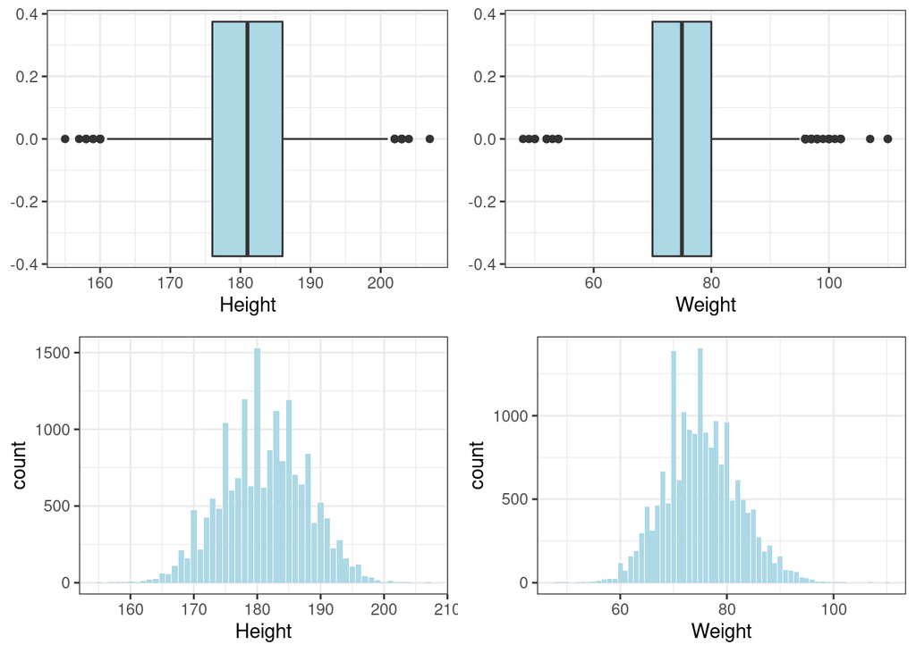

```r
hbp=ggplot(fifa2017,aes(x=Height,fill=Height))+geom_boxplot(fill="lightblue")+theme_bw()
hb=ggplot(fifa2017,aes(x=Height,fill=Height))+geom_bar(fill="lightblue")+theme_bw()

wbp=ggplot(fifa2017,aes(x=Weight,fill=Weight))+geom_boxplot(fill="lightblue")+theme_bw()
wb=ggplot(fifa2017,aes(x=Weight,fill=Weight))+geom_bar(fill="lightblue")+theme_bw()

grid.arrange(grobs = list(hbp, wbp, hb, wb) , nrow = 2, ncol = 2)
```

Al verlo graficamente, notamos que los valores extremos que nos dio el summary en principio son valores “normales” al ojo humano pero que se “alejan” de la tendencia central de nuestra muestra de datos.

Con esta comando podemos de que valores se tratan estos “outliers” de la muestra:

```r
# Valores atipicos de altura
sort(boxplot.stats(fifa2017$Height)$out)
```

```
##  [1] 155 157 158 158 158 159 159 160 160 160 160 160 160 202 202 202 203 203 203
## [20] 203 203 204 207
```

```r
# Valores atipicos en el peso
sort(boxplot.stats(fifa2017$Weight)$out)
```

```
##  [1]  48  49  50  50  52  52  52  53  54  54  54  96  96  96  96  96  96  96  96
## [20]  96  96  96  96  96  96  96  96  96  96  96  96  96  97  97  97  97  97  98
## [39]  98  98  98  98  98  99 100 100 100 100 101 102 102 102 107 110 110
```

Podriamos optar aqui por convertirlos a NA por ser “outliers” en esta muestra, pero dado que consideramos que no son valores “anormalmente” altos o bajos en princio los dejaremos, ya que es posible que existan jugadores de 160cm como de 207cm o de 50kg como de 110kg. Es verdad que es poco probable encontrar a hombres de menos de 55kg, pero puede darse, no es un valor “incorrecto”.

Ademas tal como se menciona en los recursos de la asignatura y es nuestro caso: “En algunas ocasiones el valor atipico es cambiado por «no disponible» (NA) y, en otras ocasiones, se queda tal como está ya que puede ser un valor real pero muy poco frecuente.”

Veamos un ejemplo de jugador de bajo peso:

```r
cols = c("Name", "Age", "Weight", "Height", "Nationality")
fifa2017[fifa2017$Weight == 48,cols]
```

```
##              Name Age Weight Height Nationality
## NA           <NA>  NA     NA     NA        <NA>
## NA.1         <NA>  NA     NA     NA        <NA>
## NA.2         <NA>  NA     NA     NA        <NA>
## 15936 Julius Kade  17     48    167     Germany
```

En los puntos siguientes de esta practica igualmente podremos validar al momento de realizar el EDA y PCA que sucede con y sin estos valores no tan “tipicos” (si es que vemos que estos valores desvirtuan el analisis) simplemente convirtiendo en NA el peso y la altura de estas **pocas** observaciones que desplegamos aqui:

```r
# Pesos "atipicos"
fifa2017[fifa2017$Weight %in% boxplot.stats(fifa2017$Weight)$out, cols]
```

```
##                            Name Age Weight Height         Nationality
## 113               Medhi Benatia  29     96    190             Morocco
## 196                Jonathan Tah  20     98    194             Germany
## 575          Jannik Vestergaard  24     98    199             Denmark
## 899             Alexander Meier  33     96    196             Germany
## 1062          Costel Pantilimon  29     96    203             Romania
## 1126            Sebastian Prödl  29     97    196             Austria
## 1806                 Bill Hamid  26    102    191       United States
## 2127             Kendall Waston  29     97    196          Costa Rica
## 2920              Kim Shin Wook  28     97    197      Korea Republic
## 3090                 John Ruddy  30     96    193             England
## 3156                 Tom Starke  35     98    194             Germany
## 3370               Román Torres  30     96    187              Panama
## 3537              Michael Esser  29     99    198             Germany
## 3542            Lars Unnerstall  26    100    198             Germany
```

[output cut: 41 more lines]

```r
# Alturas "atipicas"
fifa2017[fifa2017$Height %in% boxplot.stats(fifa2017$Height)$out, cols]
```

```
##                         Name Age Weight Height   Nationality
## 1062       Costel Pantilimon  29     96    203       Romania
## 1466            Maxi Moralez  29     56    158     Argentina
## 1789           Lacina Traoré  26     87    203   Ivory Coast
## 2245              Joao Plata  24     61    157       Ecuador
## 2504                Élton Na  30     59    159        Brazil
## 2932         Daniel Villalva  24     61    158     Argentina
## 3845      Christian Bermúdez  29     61    160        Mexico
## 5671        Cristian Techera  24     68    158       Uruguay
## 6716           Erhun Oztumer  25     60    160       England
## 8359        Kristof Van Hout  29    110    207       Belgium
## 8617        Misael Domínguez  17     58    159        Mexico
## 8857  Vanja Milinkovic-Savic  19     92    202        Serbia
## 9472       Stefan Maierhofer  34     98    202       Austria
## 9693                     Idé  23     96    204 Guinea Bissau
## 10334              Torric Na  25     57    160         Ghana
## 10792       Yeferson Soteldo  19     55    160     Venezuela
## 12830           Fejsal Mulic  22     93    203        Serbia
## 13410        Hiroto Nakagawa  22     57    155         Japan
## 14627         Agustín Araujo  17     59    160     Argentina
## 15393          Aaron Chapman  26     92    203       England
## 16168         Jorge Calderón  22     56    160        Mexico
## 16839           Mikkel Qvist  23     80    203       Denmark
## 17257            Demba Thiam  18     81    202       Senegal
```

# 7. Imputación de valores

Buscar en las variables Weight y Height donde haya valores perdidos (NA) y realice una imputación de valores. Para realizar una imputación de valores necesita hacer una regresión lineal que tenga como variable a predecir la variable con la NAs. Esto significa que hay que realizar dos modelos de regresión lineal, uno para predecir los valores NAs en Weight a partir de la variable Height. El otro es precisamente al revés, predecir los valores NAs en Height a partir de Weight. La función para hacer regresión lineal es lm().

Muestre el resultado de la imputación y de la variable explicativa en aquellos casos donde había un NA.

Identifiquemos primero los registros con NA de ambas variables

```r
na_height = which(is.na(fifa2017$Height))
na_weight = which(is.na(fifa2017$Weight))
cols = c("Name", "Age", "Weight", "Height", "Nationality")
fifa2017[na_height, cols]
```

```
##                 Name Age Weight Height Nationality
## 2       Lionel Messi  29     72     NA   Argentina
## 6             De Gea  26     82     NA       Spain
## 9 Zlatan Ibrahimovic  35     95     NA      Sweden
```

```r
fifa2017[na_weight, cols]
```

```
##                 Name Age Weight Height Nationality
## 1  Cristiano Ronaldo  31     NA    185    Portugal
## 5       Manuel Neuer  30     NA    193     Germany
## 7 Robert Lewandowski  28     NA    185      Poland
```

Creemos y visualicemos los modelos

```r
height_model = lm(fifa2017$Height ~ fifa2017$Weight)
weight_model = lm(fifa2017$Weight ~ fifa2017$Height)
height_model
```

```
##
## Call:
## lm(formula = fifa2017$Height ~ fifa2017$Weight)
##
## Coefficients:
##     (Intercept)  fifa2017$Weight
##        125.8960           0.7336
```

```r
weight_model
```

```
##
## Call:
## lm(formula = fifa2017$Weight ~ fifa2017$Height)
##
## Coefficients:
##     (Intercept)  fifa2017$Height
##        -66.6175           0.7834
```

Imputemos los valores obtenidos por la prediccion y visualicemos los resultados:

```r
fifa2017[na_height, "Height"] = as.integer(predict(height_model, newdata = fifa2017[na_height,])[na_height])
fifa2017[na_weight, "Weight"] = as.integer(predict(weight_model, newdata = fifa2017[na_weight,])[na_weight])
# Asi fue la prediccion para las alturas
fifa2017[na_height, cols]
```

```
##                 Name Age Weight Height Nationality
## 2       Lionel Messi  29     72    178   Argentina
## 6             De Gea  26     82    186       Spain
## 9 Zlatan Ibrahimovic  35     95    195      Sweden
```

```r
# Y asi el resultado de la prediccion de los pesos
fifa2017[na_weight, cols]
```

```
##                 Name Age Weight Height Nationality
## 1  Cristiano Ronaldo  31     78    185    Portugal
## 5       Manuel Neuer  30     84    193     Germany
## 7 Robert Lewandowski  28     78    185      Poland
```

# 8. Estudio descriptivo de las variables cuantitativas.

Realice un breve estudio descriptivo de las variables cuantitativas una vez depuradas. Hay que crear una tabla con medidas de tendencia central y de dispersión, tanto robustas como no robustas. Haga un breve comentario sobre los resultados obtenidos entre estos tipos de medidas en todas las variables.

Luego de haber normalizado la mayoria de las variables veamos como quedo nuestro dataframe:

```r
str(fifa2017)
```

```
## 'data.frame':    17588 obs. of  54 variables:
##  $ ID                : int  1 2 3 4 5 6 7 8 9 10 ...
##  $ Name              : chr  "Cristiano Ronaldo" "Lionel Messi" "Neymar" "Luis Suárez" ...
##  $ Nationality       : chr  "Portugal" "Argentina" "Brazil" "Uruguay" ...
##  $ National_Position : chr  "LS" "RW" "LW" "LS" ...
##  $ National_Kit      : int  7 10 10 9 1 1 9 11 NA 1 ...
##  $ Club              : chr  "Real Madrid" "FC Barcelona" "FC Barcelona" "FC Barcelona" ...
##  $ Club_Position     : chr  "LW" "RW" "LW" "ST" ...
##  $ Club_Kit          : int  7 10 11 9 1 1 9 11 9 13 ...
##  $ Club_Joining      : Date, format: "2009-07-01" "2004-07-01" ...
##  $ Contract_Expiry   : int  2021 2018 2021 2021 2021 2019 2021 2022 2017 2019 ...
##  $ Rating            : int  94 93 92 92 92 90 90 90 90 89 ...
##  $ Height            : int  185 178 174 182 193 186 185 183 195 199 ...
##  $ Weight            : int  78 72 68 85 84 82 78 74 95 91 ...
##  $ Preffered_Foot    : chr  "Right" "Left" "Right" "Right" ...
```

[output cut: 40 more lines]

Quedemosnos con algunas variables cuantitivas para realizar un estudio descriptivo

```r
cols = c("Rating", "Height", "Weight", "Age", "Ball_Control", "Dribbling", "Freekick_Accuracy", "Shot_Power")
```

Tal como se comenta en los recursos de aprendizaje se puede hacer uso del paquete psych para utilizar estimadores robustos a la hora de describir las variables de una muestra.

Pero antes de continuar realizamos un breve repaso de los estimadores mas comunes:

**Estimadores de Tendencia Central:**

```
- El estimador de tendencia central clásico es la media aritmética. Tiene muy buenas propiedades; es un estimador insesgado,
pero su estimación está muy influida por los valores atípicos.

- La mediana es uno de los estimadores robustos más conocidos para medir la tendencia central de los datos.

- Otro estimador robusto para medir la tendencia central es la media recortada (trimmed mean).

- Una variante de la media recortada es la media winsorizada (winsorized mean).
```

**Estimadores de Dispersion:**

```
- Para medir la dispersión de los datos el estimador más habitual es la desviación estándar, que no es un estimador robusto.

- El rango intercuartílico (RIC) y la desviación absoluta respecto de la mediana (DAM) son alternativas robustas a la desviación estándar
```

Ahora si veamos estos estimadores en numeros con la ayuda de psych

```r
describe(fifa2017[cols], na.rm = TRUE,  IQR = TRUE, trim=.05 )
```

```
##                   vars     n   mean    sd median trimmed   mad min max range
## Rating               1 17588  66.17  7.08     66   66.16  7.41  45  94    49
## Height               2 17588 181.11  6.67    181  181.11  7.41 155 207    52
## Weight               3 17588  75.25  6.90     75   75.16  7.41  48 110    62
## Age                  4 17588  25.14  4.68     25   24.99  4.45  16  47    31
## Ball_Control         5 17588  57.97 16.83     63   59.05 11.86   5  95    90
## Dribbling            6 17588  54.80 18.91     60   55.80 13.34   4  97    93
## Freekick_Accuracy    7 17588  43.38 17.70     42   43.30 19.27   4  93    89
## Shot_Power           8 17588  55.58 17.60     59   56.25 16.31   3  93    90
##                    skew kurtosis   se IQR
## Rating            -0.02    -0.03 0.05   9
## Height            -0.03    -0.26 0.05  10
## Weight             0.21     0.09 0.05  10
## Age                0.42    -0.42 0.04   7
## Ball_Control      -1.18     0.76 0.13  16
## Dribbling         -1.00     0.14 0.14  21
## Freekick_Accuracy  0.05    -0.78 0.13  26
## Shot_Power        -0.68    -0.38 0.13  24
```

Si nos focalizamos en los estimadores de tendencia central, puede verse para la mayoria de las variables que la media recortada de un 5% se acerca mas a la mediana, estimador robusto, que la media aritmetica.

Mientras que la DAM y el RIC, en algunos casos mejora los valores mostrados por la desviacion standar, como ser el caso de Age.

# 9. Análisis de Componentes Principales (PCA)

Realizar el Análisis de Componentes Principales sobre las variables “Rating”, “Height”, “Weight” y “Age”. Representar el gráfico biplot de dos dimensiones. Hacer un breve comentario indicando el porcentaje de variabilidad explicada en cada componente principal, la variabilidad explicada en las dos primeras dimensiones y qué variable original está más asociada a cada una de las dos primeras componentes principales. Interpretar.

Por ultimo, ¿hay algún punto más fuera de la nube de puntos?, si es así puedes mostrar los valores de las variables originales e indicar que tiene de especial este punto.

Ante todo verificamos que exista correlacion entre algunas de las variables para que la aplicacion de PCA tenga sentido

```r
cols = c("Rating", "Height", "Weight", "Age")
cor(fifa2017[cols])
```

```
##           Rating    Height    Weight       Age
## Rating 1.0000000 0.0471347 0.1394514 0.4560377
## Height 0.0471347 1.0000000 0.7582051 0.0765333
## Weight 0.1394514 0.7582051 1.0000000 0.2221901
## Age    0.4560377 0.0765333 0.2221901 1.0000000
```

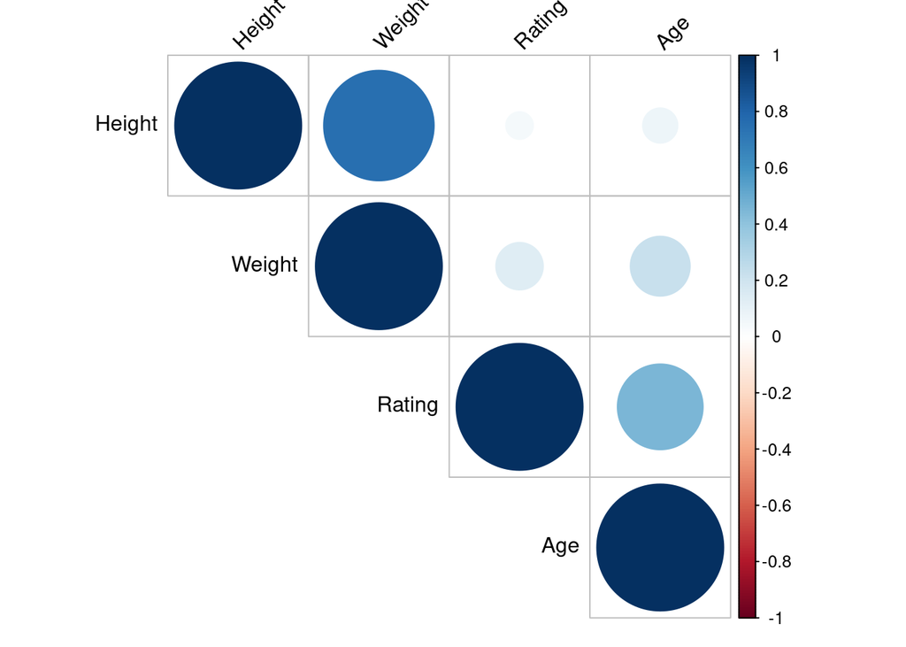

```r
corrplot(cor(fifa2017[cols]), type = "upper", order = "hclust", tl.col = "black", tl.srt = 45)
```

Al menos tenemos una alta correlacion entre el peso y la altura, como era de esperar. Y poca entre el rating y la edad. Y casi nula entre estos 2 grupos de variables.

Veamos la proporcion de varianza explicada con cada variable aplicando PCA mediante el uso de la matriz de las correlaciones. Utilizamos este metodo dado que las variables de analisis tienen magnitudes distintas, cm para la altura, kg para el peso, y sin unidades para la edad y el rating.

De hecho si hacemos la comparacion entre ambos metodos vemos que si bien con ambos necesitamos 3 componentes para explicar mas del 90% de la varianza, es con con la matriz de correlaciones cuando obtenemos un minimo mejor porcentaje (94.31% vs 93.83)

```r
PCA.cor <- prcomp(x=fifa2017[cols], center = TRUE, scale.= TRUE)
PCA.cov <- prcomp(x=fifa2017[cols], center = TRUE, scale.= FALSE)
summary(PCA.cor)
```

```
## Importance of components:
##                           PC1    PC2    PC3     PC4
## Standard deviation     1.3773 1.1541 0.7374 0.47695
## Proportion of Variance 0.4742 0.3330 0.1359 0.05687
## Cumulative Proportion  0.4742 0.8072 0.9431 1.00000
```

```r
summary(PCA.cov)
```

```
## Importance of components:
##                           PC1    PC2     PC3     PC4
## Standard deviation     9.1630 7.3712 3.96670 3.18121
## Proportion of Variance 0.5115 0.3310 0.09586 0.06165
## Cumulative Proportion  0.5115 0.8425 0.93835 1.00000
```

Vale aclarar que si usaramos por ejemplo solo dos componentes, con la matriz de covarianzas obtenemos una mayor varianza explicada a pesar que las magnitudes de las variables sean diferentes, 84.25% vs 80.72%. Por lo que si nos fuera suficiente solo un 80% minimo de la varianza podriamos optar por usar las dos primeras componenetes usando covarianzas.

Tal como se describe en los recursos de aprendizaje, la varianza de cada componente principal es el valor propio y se calcula elevando al cuadrado PCA.cov$sdev (o PCA.cor$sdev para correlaciones). Para obtener el porcentaje de la varianza explicada en cada componente principal hay que dividir cada valor propio entre la suma de todos los valores propios, y da un resultado de 51.15%, 33.1%, 9.5%, 6.1% (covarianzas). Así que como se dijo en el parrafo anterior las 2 primeras componentes puede resumir un 84.25% de varianza de las cuatro variables originales.

Dicho todo esto, se podria realizar una reduccion a dos componentes usando covarianzas si es que con un minimo de 80% de la varianza estamos ok, o una reduccion a 3 componentes usando correlaciones si es que necesitamos explicar un minimo del 90%.

Esta conclusiones fueron realizada suponiendo que queremos por definicion explicar tanto porcentaje de la varianza, pero veamos ahora con dos de los criterios habituales para decidir el número de componentes principales a seleccionar:

- la regla de Kaiser-Guttman y
- el test de scree

## Eleccion del numero de componentes

### Componentes con Covarianzas

En el caso de realizar el PCA con la matriz de covarianzas, los valores propios son 83.95979 54.33519 15.73471 10.12013, y su valor medio es 41.03745. Aplicando el criterio de Kaiser-Gutman es suficiente con seleccionar 2 dos primeras componentes.

```r
ValoresPropios.cov = PCA.cov$sdev**2
ValoresPropios.cov
```

```
## [1] 83.95979 54.33519 15.73471 10.12013
```

```r
mean(ValoresPropios.cov)
```

```
## [1] 41.03745
```

Mientras que con el test de scree vemos que la curva comienza a suavizarse desde el 3, por lo que con las dos primeras componentes estariamos ok, incluso podria usarse la 3ra.

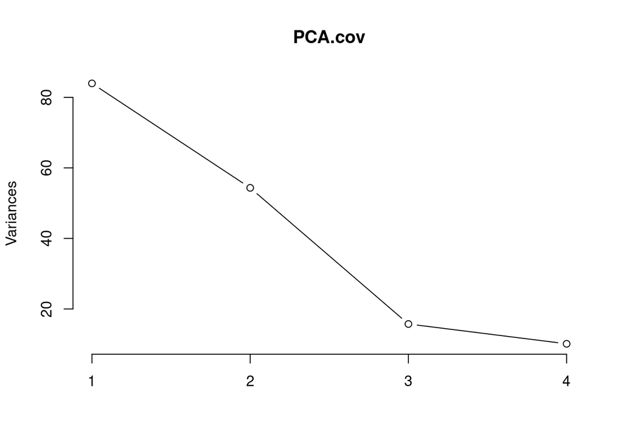

```r
screeplot(PCA.cov, type = c("lines"))
```

### Componentes con Correlaciones

```r
ValoresPropios.cor = PCA.cor$sdev**2
ValoresPropios.cor
```

```
## [1] 1.8968406 1.3319478 0.5437291 0.2274825
```

```r
mean(ValoresPropios.cor)
```

```
## [1] 1
```

Y aqui con scree no queda muy claro donde esta el codo, pero podria ser en 3.

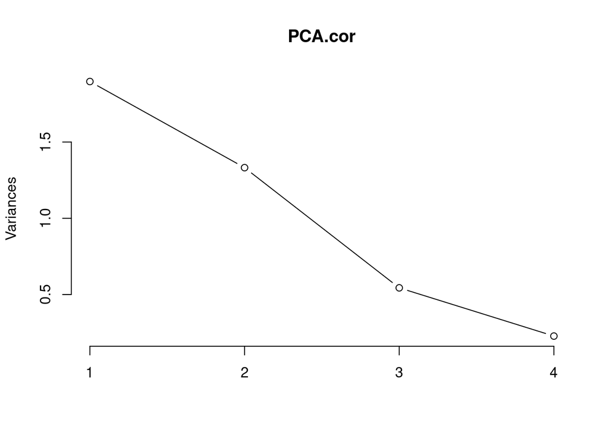

```r
screeplot(PCA.cor,  npcs = min(10, length(PCA.cor$sdev)),type = c("lines"))
```

### Representación de los datos en dimensión reducida

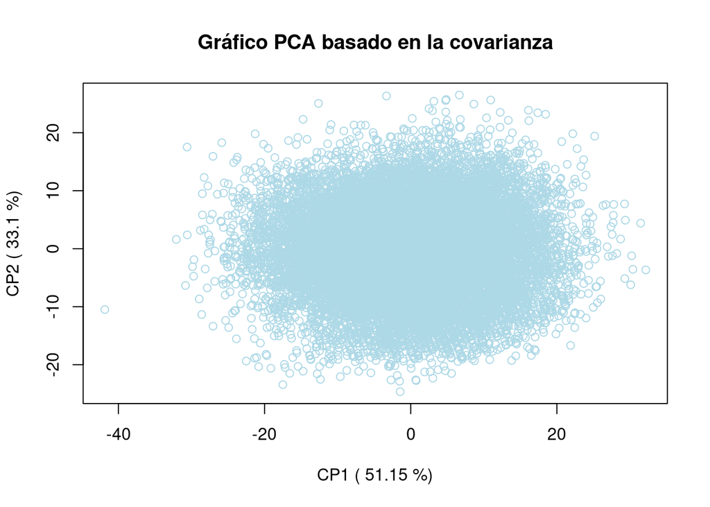

```r
# % de varianza explicada en cada componente principal, usando covarianzas
var.exp.cov <- (PCA.cov$sdev^2 / sum(PCA.cov$sdev^2))*100

plot(PCA.cov$x[,1],PCA.cov$x[,2],
xlab = paste("CP1 (", round(var.exp.cov[1],2),"%)"),
ylab = paste("CP2 (", round(var.exp.cov[2],2),"%)"),
main = "Gráfico PCA basado en la covarianza",
col=c("lightblue")
 )
```

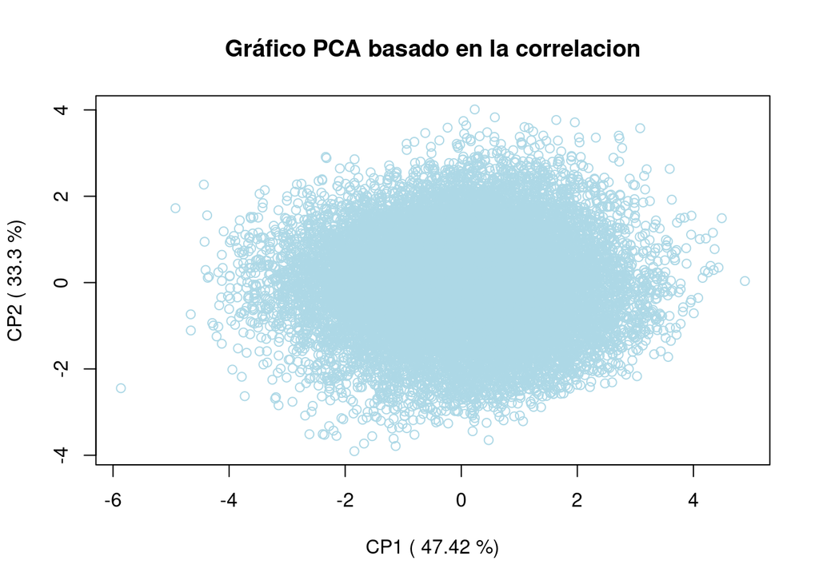

```r
# % de varianza explicada en cada componente principal, usando correlaciones
var.exp.cor <- (PCA.cor$sdev^2 / sum(PCA.cor$sdev^2))*100

plot(PCA.cor$x[,1],PCA.cor$x[,2],
xlab = paste("CP1 (", round(var.exp.cor[1],2),"%)"),
ylab = paste("CP2 (", round(var.exp.cor[2],2),"%)"),
main = "Gráfico PCA basado en la correlacion",
col=c("lightblue")
 )
```

Por lo que vemos aqui no es posible sacar ninguna conclusion con dos componentes principales sobre solo algunas (4 variables) columnas de nuestro dataset original. Habria que agregar mas variables al dataset para aplicar PCA e incluso alguna variables sobre la que querramos clasifcar en colores para poder asi discernir entre las observaciones sobre un valor de interes.

Veamos rapido una representacion agregando mas variables al aplicar PCA usando correlaciones y analicemos si obtenemos algun dato relevante.

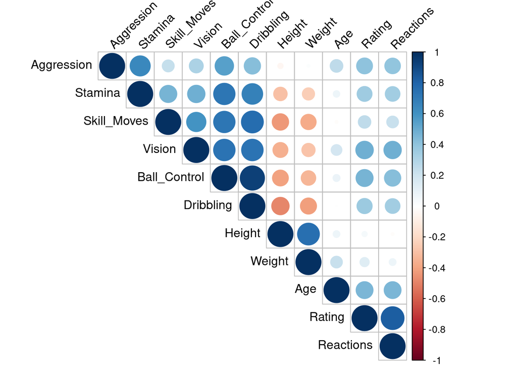

```r
cols = c("Rating", "Height", "Weight", "Age", "Skill_Moves", "Ball_Control", "Dribbling", "Aggression", "Reactions", "Vision", "Stamina")
corrplot(cor(fifa2017[cols]), type = "upper", order = "hclust", tl.col = "black", tl.srt = 45)
```

```r
pca_fifa2017 <- prcomp(x=fifa2017[cols], center = TRUE, scale.= TRUE)
summary(pca_fifa2017)
```

```
## Importance of components:
##                           PC1    PC2     PC3    PC4     PC5     PC6     PC7
## Standard deviation     2.2351 1.5365 1.01132 0.8912 0.74858 0.58952 0.52922
## Proportion of Variance 0.4542 0.2146 0.09298 0.0722 0.05094 0.03159 0.02546
## Cumulative Proportion  0.4542 0.6688 0.76176 0.8340 0.88491 0.91650 0.94196
##                            PC8     PC9    PC10    PC11
## Standard deviation     0.47576 0.44099 0.40332 0.23438
## Proportion of Variance 0.02058 0.01768 0.01479 0.00499
## Cumulative Proportion  0.96254 0.98022 0.99501 1.00000
```

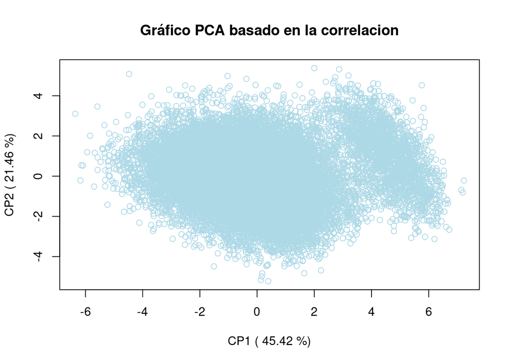

```r
pca_fifa2017.cor <- (pca_fifa2017$sdev^2 / sum(pca_fifa2017$sdev^2))*100
plot(pca_fifa2017$x[,1],pca_fifa2017$x[,2],
xlab = paste("CP1 (", round(pca_fifa2017.cor[1],2),"%)"),
ylab = paste("CP2 (", round(pca_fifa2017.cor[2],2),"%)"),
main = "Gráfico PCA basado en la correlacion",
col = c('lightblue')
 )
```

Entender el vector de loadings que forma cada componente nos puede ayudar a interpretar que clase de información capta cada componente, por ejemplo si miramos la componente 1:

```r
sort(pca_fifa2017$rotation[,'PC1'], decreasing =TRUE)
```

```
##       Height       Weight          Age    Reactions   Aggression       Rating
##   0.21825424   0.17613118  -0.09402414  -0.26146871  -0.26397930  -0.26533561
##  Skill_Moves      Stamina       Vision    Dribbling Ball_Control
##  -0.33446096  -0.34503450  -0.36405904  -0.40697392  -0.41829263
```

Esto lo podemos visualizar con un grafico de contribucion donde veremos mas simplemente las variables originales mas representadas en cada componente:

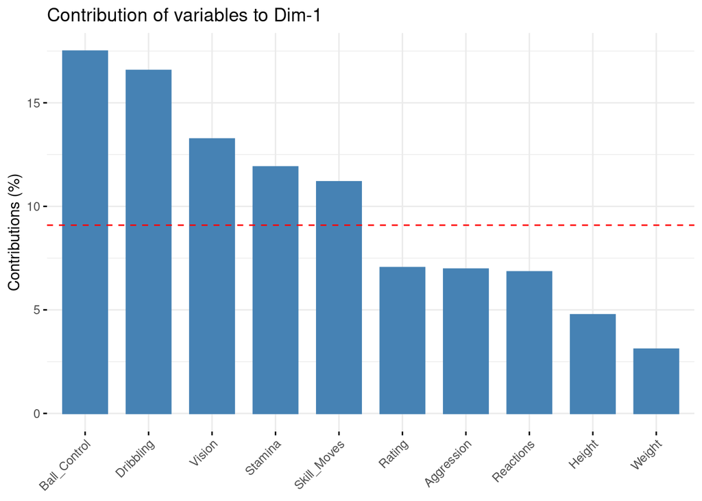

```r
#componente 1
fviz_contrib(pca_fifa2017,choice='var',axes=1, top = 10)
```

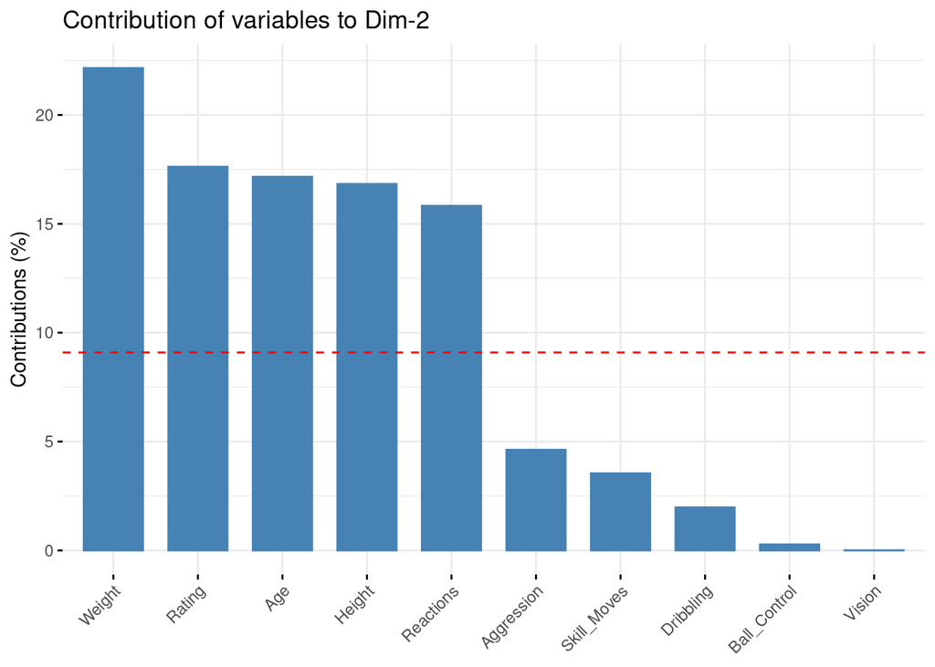

```r
#componente 2
fviz_contrib(pca_fifa2017,choice='var',axes=2, top = 10)
```

Mismo podriamos combinar en un mismo grafico las dos primeras componentes para entender entre las dos cuales son las mas influyentes, veamoslo:

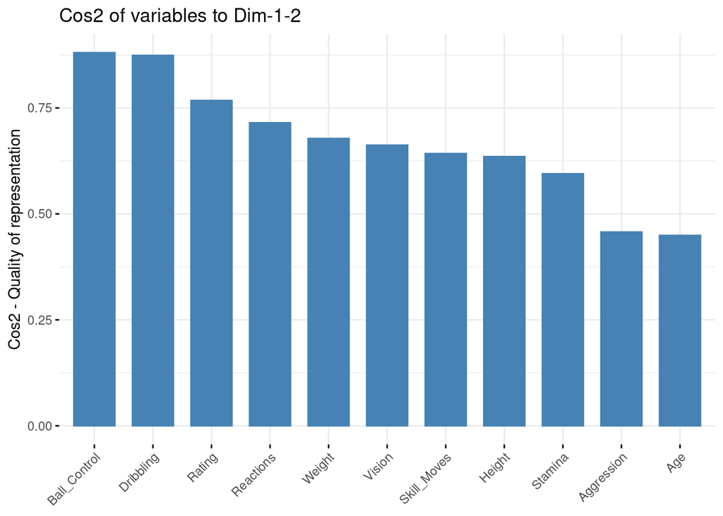

```r
fviz_cos2(pca_fifa2017,choice='var',axes=1:2)
```

Esto es importante saber ya que cuando contamos con muchas variables, podríamos decidir mostrar solo aquellas con mayor contribución.

Y asi podriamos seguir analizando el resto de las componentes para entender que variables tienen mas pesos sobre otras, o incluso agregando todas las variables del dataset original para que sea input de PCA e ir ajustando el analisis y entender si usando todas las caracteristicas de los jugadores nos permiten descubrir insights.

Veamos como se ven en un grafico de dos dimesiones al menos las primeras dos componentes, tanto aplicando pca con el dataset de 4 variables como el dataset de 11 variables que creamos posteriormente :

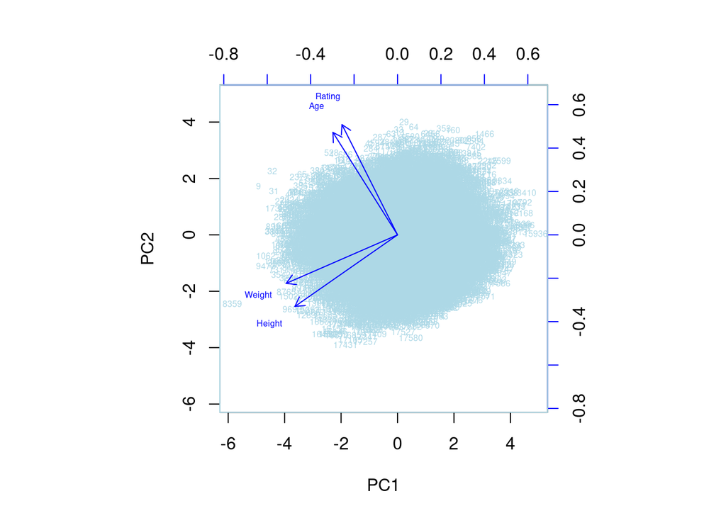

```r
biplot(x = PCA.cor, scale = 0, cex = 0.5, col = c("lightblue", "blue"))
```

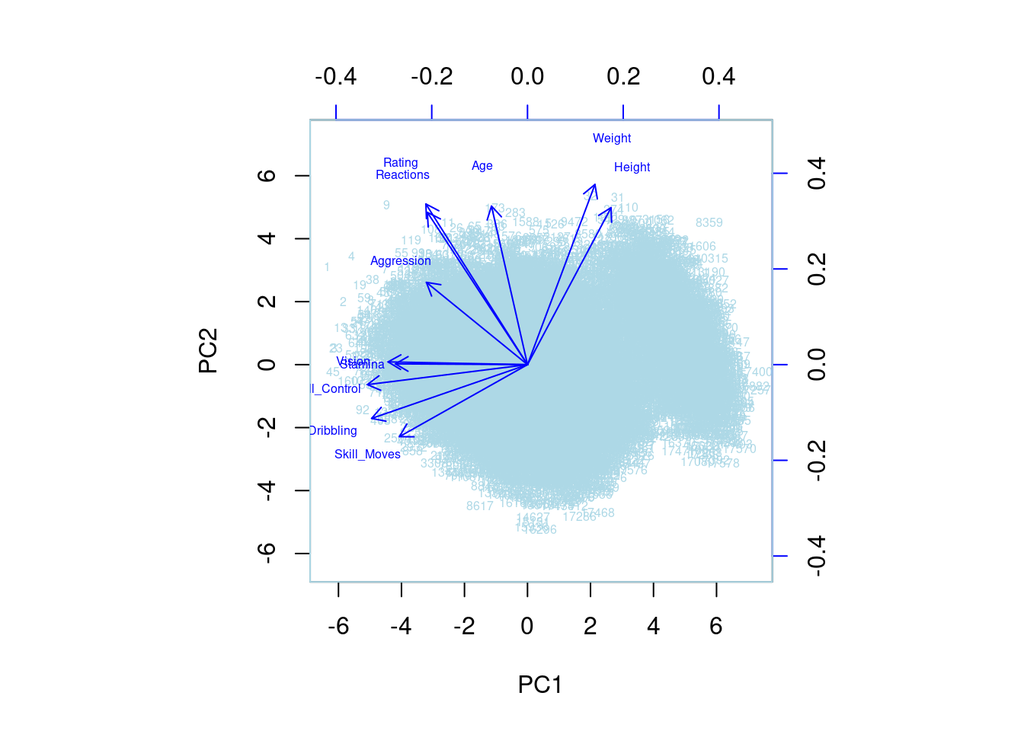

```r
biplot(x = pca_fifa2017, scale = 0, cex = 0.5, col = c("lightblue", "blue"))
```

En esta ultimo grafico vemos en la misma direccion 3 grupos de variables, varias que implican habilidad tecnica, otra la fuerza o agresividad deportiva, y la 3ra caracteristicas fisicas. Pero podemos ver que las caracteristicas fisicas nada tienen que ver con la habilidades de un jugador. Lo mismo que la edad, para nada tiene que ver con sus habilidades.

### Analisis de outliers

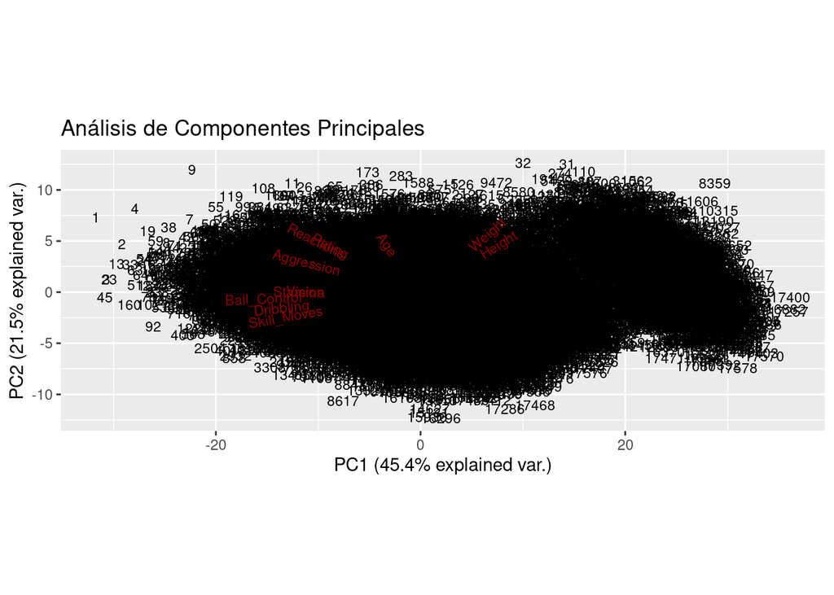

```r
#install.packages("remotes")
#remotes::install_github("vqv/ggbiplot")
library(ggbiplot)
biplot_outliers <- ggbiplot(pca_fifa2017, scale = 3, obs.scale = 3, labels = 1:17588)  +
ggtitle("Análisis de Componentes Principales")
biplot_outliers
```

Los puntos mas alejados de la nube son el 1, 2, 4, 9, 32 y 8359. Veamos estas observaciones en el dataset:

```r
rows = c(1, 2, 4, 9, 32, 8359)
fifa2017[rows,]
```

```
##        ID               Name Nationality National_Position National_Kit
## 1       1  Cristiano Ronaldo    Portugal                LS            7
## 2       2       Lionel Messi   Argentina                RW           10
## 4       4        Luis Suárez     Uruguay                LS            9
## 9       9 Zlatan Ibrahimovic      Sweden                             NA
## 32     32   Gianluigi Buffon       Italy                GK            1
## 8359 8359   Kristof Van Hout     Belgium                             NA
##                Club Club_Position Club_Kit Club_Joining Contract_Expiry Rating
## 1       Real Madrid            LW        7   2009-07-01            2021     94
## 2      FC Barcelona            RW       10   2004-07-01            2018     93
## 4      FC Barcelona            ST        9   2014-07-11            2021     92
## 9    Manchester Utd            ST        9   2016-07-01            2017     90
## 32         Juventus            GK        1   2001-07-01            2018     88
## 8359   KVC Westerlo           Sub        1   2015-07-01            2017     67
##      Height Weight Preffered_Foot Birth_Date Age Preffered_Position
```

[output cut: 48 more lines]

Mas alla que 3 de estos outliers sean observaciones a las que les hemos estimado peso o altura, que sean outliers la causa pueda ser que en escencia son jugadores atipicos y mucho mejores que la “media”. Mientras que el 8359, si bien su peso y altura son posibles en la realidad, no son tan tipicas en el mundo de los jugadores de futbol, pero claro es un Arquero, en general son altos, pero este lo es bastante. A pesar de tener nosotros este conocimiento externo de las caracteristica de los jugadores, en casos de muestras no tan conocidas, una opcion seria volver a realizar PCA con todas las variables numericas como comentamos antes o realizar PCA quitando los “outliers” que tambien comentamos antes, o incluso combinacion de ambas.

Tal como estamos descubriendo el mundo del analisis de los datos no es un proceso estatico o no existe una “receta” estrica a seguir para obtener un resultado preciso. Es un proceso continuo e iterativo el cual hay que seguir hasta obtener posibles insights o el objetivo deseado.

Al usar varianzas PCA es sensible a los outliers, es por eso que existen alternativas de PCA basadas en estimadores robustos tal como es ejemplificado en esta publicacion: **https://rpubs.com/Joaquin_AR/578072**

# 10. Archivo final

El resultado del pre procesamiento del archivo fifa.csv se guarda en el archivo “apellido_fichero_clean.csv”.

```r
write.csv(fifa2017, 'delgado_fichero_clean.csv', row.names = FALSE)
```

# Referencias

https://www.rdocumentation.org/packages/stringr/versions/1.4.0

https://stackoverflow.com/questions/6364783/capitalize-the-first-letter-of-both-words-in-a-two-word-string

https://rdrr.io/cran/eeptools/man/age_calc.html

https://www.rdocumentation.org/packages/psych/versions/2.0.12